# 통계학응용특강

기지훈 박남욱 윤승욱

Pizza Restaurant Sales

# Questions for analysis

1. 식당의 가장 바쁜 날짜와 시간
2. 바쁜기간에 만드는 피자의 수
3. 가장 많이 팔리는 피자와 적게 팔리는 피자

```r
library(tidyverse)
library(readxl)
library(lubridate)
library(janitor)
pizza.orders<- read_excel("Data Model - Pizza Sales.xlsx")
head(pizza.orders)
```

| order_details_id | order_id | pizza_id | quantity | order_date | order_time | unit_price | total_price | pizza_size | pizza_category | pizza_ingredients | pizza_name |
| --- | --- | --- | --- | --- | --- | --- | --- | --- | --- | --- | --- |
| 1 | 1 | hawaiian_m | 1 | 2015-01-01 | 1899-12-31 11:38:36 | 13.25 | 13.25 | M | Classic | Sliced Ham, Pineapple, Mozzarella Cheese | The Hawaiian Pizza |
| 2 | 2 | classic_dlx_m | 1 | 2015-01-01 | 1899-12-31 11:57:40 | 16.00 | 16.00 | M | Classic | Pepperoni, Mushrooms, Red Onions, Red Peppers, Bacon | The Classic Deluxe Pizza |
| 3 | 2 | five_cheese_l | 1 | 2015-01-01 | 1899-12-31 11:57:40 | 18.50 | 18.50 | L | Veggie | Mozzarella Cheese, Provolone Cheese, Smoked Gouda Cheese, Romano Cheese, Blue Cheese, Garlic | The Five Cheese Pizza |
| 4 | 2 | ital_supr_l | 1 | 2015-01-01 | 1899-12-31 11:57:40 | 20.75 | 20.75 | L | Supreme | Calabrese Salami, Capocollo, Tomatoes, Red Onions, Green Olives, Garlic | The Italian Supreme Pizza |
| 5 | 2 | mexicana_m | 1 | 2015-01-01 | 1899-12-31 11:57:40 | 16.00 | 16.00 | M | Veggie | Tomatoes, Red Peppers, Jalapeno Peppers, Red Onions, Cilantro, Corn, Chipotle Sauce, Garlic | The Mexicana Pizza |
| 6 | 2 | thai_ckn_l | 1 | 2015-01-01 | 1899-12-31 11:57:40 | 20.75 | 20.75 | L | Chicken | Chicken, Pineapple, Tomatoes, Red Peppers, Thai Sweet Chilli Sauce | The Thai Chicken Pizza |

#data

order_id: 테이블에 의해 배치된 각 주문에 대한 고유 식별자

order_details_id: 각 주문에 포함된 각 피자의 고유 식별자(동일한 유형 및 크기의 피자는 동일한 행에 보관되고 수량이 증가함)

pizza_id: 주문한 피자를 크기 및 가격과 같은 세부 정보와 연결하는 고유 키 식별자

quantity: 동일한 종류와 크기의 피자 각 주문수량

order_date: 주문한 날짜 (요리 및 서빙 전에 시스템에 입력)

order_time: 주문이 접수된 시간(요리 및 서빙 전에 시스템에 입력됨)

unit_price: 피자 가격(USD)

total_price: unit_price * 수량

pizza_size: 피자의 크기(소형, 중형, 대형, X 대형, XX 대형)

pizza_type: 주문한 피자를 크기 및 가격과 같은 세부 정보와 연결하는 고유 키 식별자

pizza_ingredients: 메뉴에 표시된대로 피자에 사용 된 재료 (명시되지 않은 경우에도 모두 모짜렐라 치즈를 포함하며 다른 소스가 지정되지 않는 한 모두 토마토 소스를 포함합니다)

pizza_name: 메뉴에 표시된 피자의 이름

# data str

```r
dim(pizza.orders)
```

```
## [1] 48620    12
```

```r
sum(is.na(pizza.orders)) ## 결측값 존재 하지않음
```

```
## [1] 0
```

```r
str(pizza.orders)
```

```
## tibble [48,620 × 12] (S3: tbl_df/tbl/data.frame)
##  $ order_details_id : num [1:48620] 1 2 3 4 5 6 7 8 9 10 ...
##  $ order_id         : num [1:48620] 1 2 2 2 2 2 3 3 4 5 ...
##  $ pizza_id         : chr [1:48620] "hawaiian_m" "classic_dlx_m" "five_cheese_l" "ital_supr_l" ...
##  $ quantity         : num [1:48620] 1 1 1 1 1 1 1 1 1 1 ...
##  $ order_date       : POSIXct[1:48620], format: "2015-01-01" "2015-01-01" ...
##  $ order_time       : POSIXct[1:48620], format: "1899-12-31 11:38:36" "1899-12-31 11:57:40" ...
##  $ unit_price       : num [1:48620] 13.2 16 18.5 20.8 16 ...
##  $ total_price      : num [1:48620] 13.2 16 18.5 20.8 16 ...
##  $ pizza_size       : chr [1:48620] "M" "M" "L" "L" ...
##  $ pizza_category   : chr [1:48620] "Classic" "Classic" "Veggie" "Supreme" ...
##  $ pizza_ingredients: chr [1:48620] "Sliced Ham, Pineapple, Mozzarella Cheese" "Pepperoni, Mushrooms, Red Onions, Red Peppers, Bacon" "Mozzarella Cheese, Provolone Cheese, Smoked Gouda Cheese, Romano Cheese, Blue Cheese, Garlic" "Calabrese Salami, Capocollo, Tomatoes, Red Onions, Green Olives, Ga…
##  $ pizza_name       : chr [1:48620] "The Hawaiian Pizza" "The Classic Deluxe Pizza" "The Five Cheese Pizza" "The Italian Supreme Pizza" ...
```

## 1. 식당의 가장 바쁜 날짜와 시간

월, 요일, 시간,변수를만들어 주겠습니다.

```r
pizza_orders<-pizza.orders%>%
  mutate(hour = hour(order_time),
         month = month(order_date,label = T),
         weekday = wday(order_date,label = T))
head(pizza_orders)
```

| order_details_id | order_id | pizza_id | quantity | order_date | order_time | unit_price | total_price | pizza_size | pizza_category | pizza_ingredients | pizza_name | hour | month | weekday |
| --- | --- | --- | --- | --- | --- | --- | --- | --- | --- | --- | --- | --- | --- | --- |
| 1 | 1 | hawaiian_m | 1 | 2015-01-01 | 1899-12-31 11:38:36 | 13.25 | 13.25 | M | Classic | Sliced Ham, Pineapple, Mozzarella Cheese | The Hawaiian Pizza | 11 | 1월 | 목 |
| 2 | 2 | classic_dlx_m | 1 | 2015-01-01 | 1899-12-31 11:57:40 | 16.00 | 16.00 | M | Classic | Pepperoni, Mushrooms, Red Onions, Red Peppers, Bacon | The Classic Deluxe Pizza | 11 | 1월 | 목 |
| 3 | 2 | five_cheese_l | 1 | 2015-01-01 | 1899-12-31 11:57:40 | 18.50 | 18.50 | L | Veggie | Mozzarella Cheese, Provolone Cheese, Smoked Gouda Cheese, Romano Cheese, Blue Cheese, Garlic | The Five Cheese Pizza | 11 | 1월 | 목 |
| 4 | 2 | ital_supr_l | 1 | 2015-01-01 | 1899-12-31 11:57:40 | 20.75 | 20.75 | L | Supreme | Calabrese Salami, Capocollo, Tomatoes, Red Onions, Green Olives, Garlic | The Italian Supreme Pizza | 11 | 1월 | 목 |
| 5 | 2 | mexicana_m | 1 | 2015-01-01 | 1899-12-31 11:57:40 | 16.00 | 16.00 | M | Veggie | Tomatoes, Red Peppers, Jalapeno Peppers, Red Onions, Cilantro, Corn, Chipotle Sauce, Garlic | The Mexicana Pizza | 11 | 1월 | 목 |
| 6 | 2 | thai_ckn_l | 1 | 2015-01-01 | 1899-12-31 11:57:40 | 20.75 | 20.75 | L | Chicken | Chicken, Pineapple, Tomatoes, Red Peppers, Thai Sweet Chilli Sauce | The Thai Chicken Pizza | 11 | 1월 | 목 |

월별 피자 총 판매 수

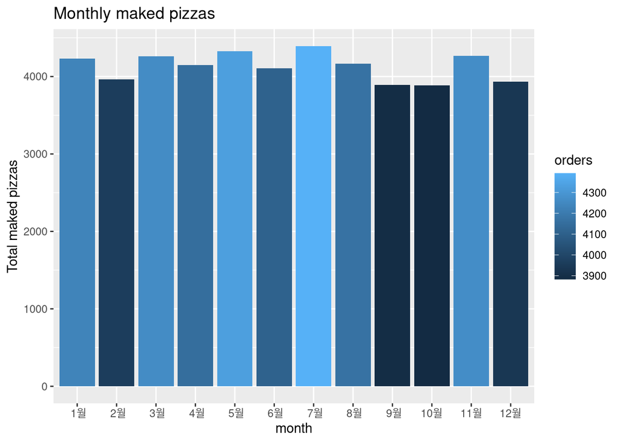

```r
pizza_orders%>%
  group_by(month)%>%
  summarize(orders = sum(quantity))%>%
  ggplot()+
  geom_col(aes(x = month, y = orders, fill= orders))+
  labs(title = "Monthly maked pizzas",y = "Total maked pizzas")
```

요일별 피자 총 판매 수

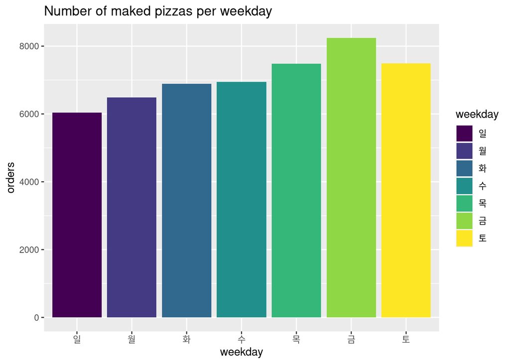

```r
pizza_orders%>%
  group_by(weekday)%>%
  summarize(orders = sum(quantity))%>%
  ggplot()+
  geom_col(aes(x = weekday,y=orders,fill=weekday))+
  labs(title = "Number of maked pizzas per weekday")
```

시간대별 피자 총 판매수

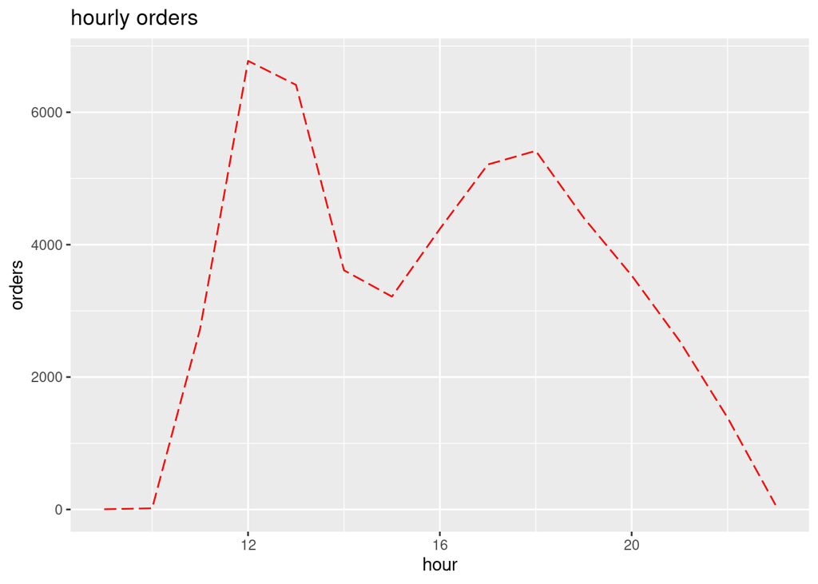

```r
pizza_orders%>%
  group_by(hour)%>%
  summarize(orders = sum(quantity))%>%
  ggplot()+
  geom_line(aes(x=hour,y=orders),linetype=5,color="red")+
  labs(title = "hourly orders")
```

요일별 매출은 예상하기 쉬운결과인 목, 금, 토에 판매량이 많았다.

시간별 매출에 관해서는 두번의 최고판매량인 시간이 있다 11시경에 증가하여 점심시간인 12시에 최고에 도달하고 두번째로 저녁시간인 18시에 다시 높은 판매량을 가진다.

##2. 바쁜기간에 만드는 피자의 수 시간별로 만들어지는 피자의 비율을 통해 비교할 것 입니다.

```r
hour_pizzas <- pizza_orders%>%
  group_by(hour)%>%
  summarize(total_pizzas = sum(quantity))%>%
  mutate(perc_order = total_pizzas/sum(total_pizzas))%>%
  mutate(perc_order = scales::percent(perc_order))

print(hour_pizzas)
```

```
## # A tibble: 15 × 3
##     hour total_pizzas perc_order
##    <int>        <dbl> <chr>
##  1     9            4 0.008%
##  2    10           18 0.036%
##  3    11         2728 5.503%
##  4    12         6776 13.668%
##  5    13         6413 12.936%
##  6    14         3613 7.288%
##  7    15         3216 6.487%
##  8    16         4239 8.551%
##  9    17         5211 10.512%
## 10    18         5417 10.927%
## 11    19         4406 8.888%
## 12    20         3534 7.129%
## 13    21         2545 5.134%
## 14    22         1386 2.796%
## 15    23           68 0.137%
```

이미 앞서서 12시와 18시에 가장 많은 피자가 판매된다는 것을 알고 있다. 12시는 6776개의 피자가 18시는 5417개의 피자가 만들어지는것을 확인 할 수 있다.

```r
rbind(hour_pizzas[4,],hour_pizzas[10,])
```

| hour | total_pizzas | perc_order |
| --- | --- | --- |
| 12 | 6776 | 13.668% |
| 18 | 5417 | 10.927% |

이제 시간을 아침 점심 저녁으로 category하여 하루 중 각 시간이 나타내는 피자의 비울을 확인해보겠습니다.

```r
pizza_orders<-pizza_orders%>%
  mutate(period =case_when(
    hour >= 6 & hour < 12 ~ "Morning",
    hour >= 12 & hour < 18 ~ "Afternoon",
    hour >= 18 & hour < 24 ~ "Evening"
  ))
head(pizza_orders)
```

| order_details_id | order_id | pizza_id | quantity | order_date | order_time | unit_price | total_price | pizza_size | pizza_category | pizza_ingredients | pizza_name | hour | month | weekday | period |
| --- | --- | --- | --- | --- | --- | --- | --- | --- | --- | --- | --- | --- | --- | --- | --- |
| 1 | 1 | hawaiian_m | 1 | 2015-01-01 | 1899-12-31 11:38:36 | 13.25 | 13.25 | M | Classic | Sliced Ham, Pineapple, Mozzarella Cheese | The Hawaiian Pizza | 11 | 1월 | 목 | Morning |
| 2 | 2 | classic_dlx_m | 1 | 2015-01-01 | 1899-12-31 11:57:40 | 16.00 | 16.00 | M | Classic | Pepperoni, Mushrooms, Red Onions, Red Peppers, Bacon | The Classic Deluxe Pizza | 11 | 1월 | 목 | Morning |
| 3 | 2 | five_cheese_l | 1 | 2015-01-01 | 1899-12-31 11:57:40 | 18.50 | 18.50 | L | Veggie | Mozzarella Cheese, Provolone Cheese, Smoked Gouda Cheese, Romano Cheese, Blue Cheese, Garlic | The Five Cheese Pizza | 11 | 1월 | 목 | Morning |
| 4 | 2 | ital_supr_l | 1 | 2015-01-01 | 1899-12-31 11:57:40 | 20.75 | 20.75 | L | Supreme | Calabrese Salami, Capocollo, Tomatoes, Red Onions, Green Olives, Garlic | The Italian Supreme Pizza | 11 | 1월 | 목 | Morning |
| 5 | 2 | mexicana_m | 1 | 2015-01-01 | 1899-12-31 11:57:40 | 16.00 | 16.00 | M | Veggie | Tomatoes, Red Peppers, Jalapeno Peppers, Red Onions, Cilantro, Corn, Chipotle Sauce, Garlic | The Mexicana Pizza | 11 | 1월 | 목 | Morning |
| 6 | 2 | thai_ckn_l | 1 | 2015-01-01 | 1899-12-31 11:57:40 | 20.75 | 20.75 | L | Chicken | Chicken, Pineapple, Tomatoes, Red Peppers, Thai Sweet Chilli Sauce | The Thai Chicken Pizza | 11 | 1월 | 목 | Morning |

```r
period_perc <- pizza_orders %>%
  group_by(period) %>%
  summarise(orders = sum(quantity)) %>%
  mutate(total_perc = orders/sum(orders)) %>%
  mutate(total_perc = scales::percent(total_perc))

## 순서형범주화
period_perc$period <- ordered(period_perc$period, levels = c("Morning", "Afternoon", "Evening"))
```

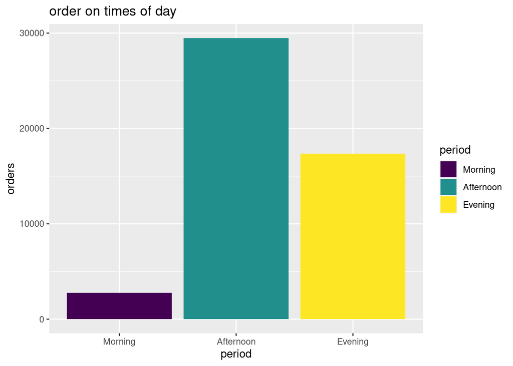

```r
ggplot(period_perc)+
  geom_col(aes(x=period, y=orders,fill=period))+
  labs(title="order on times of day")
```

```r
print(period_perc)
```

```
## # A tibble: 3 × 3
##   period    orders total_perc
##   <ord>      <dbl> <chr>
## 1 Afternoon  29468 59%
## 2 Evening    17356 35%
## 3 Morning     2750 6%
```

이 차트에서 오후 12시 부터 6시까지 가장 많은 피자가 구워지는 것을 확인 하수 있고 전체 피자의 약 60%가 afternoon에 만들어짐을 알 수 있다.

##3. 가장 많이 팔리는 피자와 적게 팔리는 피자 피자 종류별, 피자 크기별, 피자 카테고리별 판매수를 구해보겠습니다.

피자 종류별

```r
type_pizza <- pizza_orders %>%
  group_by(pizza_name) %>%
  summarise(orders = sum(quantity))

type_pizza%>%
  arrange(desc(orders))%>%
  head()
```

| pizza_name | orders |
| --- | --- |
| The Classic Deluxe Pizza | 2453 |
| The Barbecue Chicken Pizza | 2432 |
| The Hawaiian Pizza | 2422 |
| The Pepperoni Pizza | 2418 |
| The Thai Chicken Pizza | 2371 |
| The California Chicken Pizza | 2370 |

```r
type_pizza%>%
  arrange(desc(orders))%>%
  tail()
```

| pizza_name | orders |
| --- | --- |
| The Spinach Pesto Pizza | 970 |
| The Soppressata Pizza | 961 |
| The Spinach Supreme Pizza | 950 |
| The Calabrese Pizza | 937 |
| The Mediterranean Pizza | 934 |
| The Brie Carre Pizza | 490 |

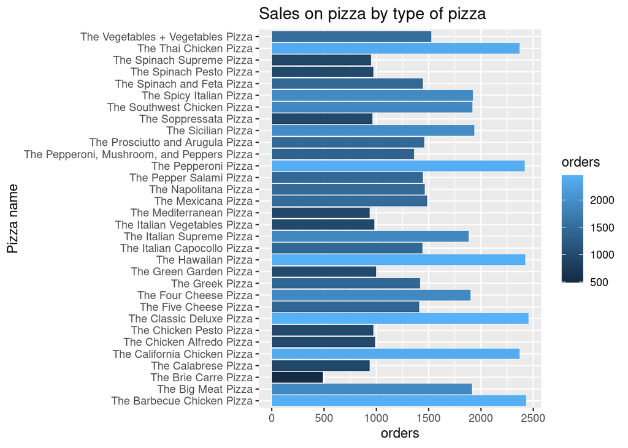

```r
  ggplot(type_pizza, aes(x = pizza_name, y = orders, fill = orders)) +
  geom_bar(stat = "identity") +
  coord_flip() +
  labs(title = "Sales on pizza by type of pizza", x = "Pizza name")
```

피자 크기별

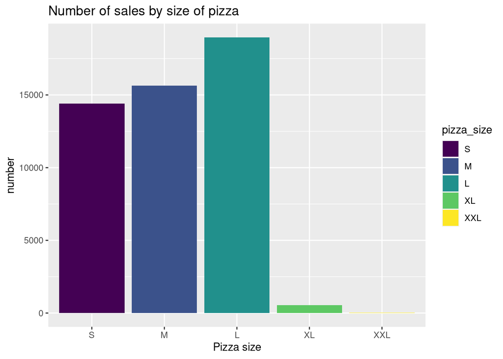

```r
size_category <- pizza_orders %>%
  group_by(pizza_size) %>%
  summarise(number = sum(quantity)) %>%
  mutate(total_perc = number/sum(number)) %>%
  mutate(total_perc = scales::percent(total_perc))

size_category$pizza_size <- ordered(size_category$pizza_size, levels = c("S", "M", "L", "XL", "XXL"))

ggplot(size_category, aes(x = pizza_size, y = number, fill = pizza_size)) +
  geom_col() +
  labs(title = "Number of sales by size of pizza", x = "Pizza size")
```

피자 카테고리별

```r
category <- pizza_orders %>%
  group_by(pizza_category) %>%
  summarise(orders = sum(quantity)) %>%
  mutate(total_perc = orders/sum(orders)) %>%
  mutate(total_perc = scales::percent(total_perc))

print(category)
```

```
## # A tibble: 4 × 3
##   pizza_category orders total_perc
##   <chr>           <dbl> <chr>
## 1 Chicken         11050 22.29%
## 2 Classic         14888 30.03%
## 3 Supreme         11987 24.18%
## 4 Veggie          11649 23.50%
```

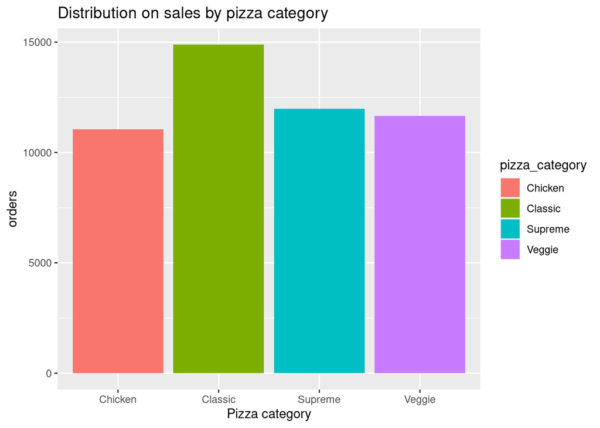

```r
ggplot(category, aes(x = pizza_category, y = orders, fill = pizza_category)) +
  geom_col() +
  labs(title = "Distribution on sales by pizza category", x = "Pizza category")
```

Classic Dluxe Pizza, Barbecue Chicken Pizza, Hawailan Pizza 순으로 대중들에게 인기가 많다.반면 The Brie Carre Pizza는 가장 인기가 없는 피자 임을 확인할 수 있다.

일반적으로 고객들은 보통 라지사이즈를 주문하는것으로 확인되었다.

피자 카테고리에 대한 선호도를 살펴보면 클래식 카테고리가 가장 높은 주문수를 가지고 나머지 카테고리들은 20%내외로 비슷한 수준을 보인다.